Adapted from https://www.w3schools.com/python/default.asp

```python
#This is a comment
print("Hello, World!")
```

```
Hello, World!
```

# Variables

```python
x = 5
y = "John"
print(x)
print(y)
x = str(3)    # x will be '3'
y = int(3)    # y will be 3
z = float(3)  # z will be 3.0
```

```
5
John
```

```python
x, y, z = "Orange", "Banana", "Cherry"
print(x)
print(y)
print(z)
```

```
Orange
Banana
Cherry
```

```python
x = y = z = "Orange"
print(x)
print(y)
print(z)
```

```
Orange
Orange
Orange
```

```python
fruits = ["apple", "banana", "cherry"]
x, y, z = fruits
print(x)
print(y)
print(z)
```

```
apple
banana
cherry
```

```python
print(x, y, z)
```

```
apple banana cherry
```

```python
print(x + y + z)
```

```
applebananacherry
```

```python
x = 5
y = 10
print(x + y)
```

```
15
```

```python
x = 5
y = "John"
print(x, y)
```

```
5 John
```

```python
x = 1    # int
y = 2.8  # float
z = 1j   # complex
print(type(x))
print(type(y))
print(type(z))
```

```
<class 'int'>
<class 'float'>
<class 'complex'>
```

```python
x = float(1)     # x will be 1.0
y = float(2.8)   # y will be 2.8
z = float("3")   # z will be 3.0
w = float("4.2") # w will be 4.2
```

```python
x = int(1)   # x will be 1
y = int(2.8) # y will be 2
z = int("3") # z will be 3
```

# Strings

```python
a = "Hello, World!"
print(a[1])
```

```
e
```

```python
for x in "banana":
  print(x)
```

```
b
a
n
a
n
a
```

```python
a = "Hello, World!"
print(len(a))
```

```
13
```

```python
#Check if "free" is present in the following text:

txt = "The best things in life are free!"
print("free" in txt)
```

```
True
```

```python
txt = "The best things in life are free!"
if "free" in txt:
  print("Yes, 'free' is present.")
```

```
Yes, 'free' is present.
```

```python
txt = "The best things in life are free!"
print("expensive" not in txt)
```

```
True
```

```python
txt = "The best things in life are free!"
if "expensive" not in txt:
  print("No, 'expensive' is NOT present.")
```

```
No, 'expensive' is NOT present.
```

```python
b = "Hello, World!"
print(b[2:5])
```

```
llo
```

```python
b = "Hello, World!"
print(b[:5])
```

```
Hello
```

```python
a = "Hello, World!"
print(a.upper())
```

```
HELLO, WORLD!
```

```python
a = "Hello, World!"
print(a.lower())
```

```
hello, world!
```

```python
#The strip() method removes any whitespace from the beginning or the end:
a = " Hello,  World! "
print(a.strip()) # returns "Hello, World!"
```

```
Hello,  World!
```

```python
a = "Hello"
b = "World"
c = a + b
print(c)
```

```
HelloWorld
```

```python
a = "Hello"
b = "World"
c = a + " " + b
print(c)
```

```
Hello World
```

```python
age = 36
txt = "My name is John, and I am {}"
print(txt.format(age))
```

```
My name is John, and I am 36
```

```python
quantity = 3
itemno = 567
price = 49.95
myorder = "I want {} pieces of item {} for {} dollars."
print(myorder.format(quantity, itemno, price))
```

```
I want 3 pieces of item 567 for 49.95 dollars.
```

```python
quantity = 3
itemno = 567
price = 49.95
myorder = "I want to pay {2} dollars for {0} pieces of item {1}."
print(myorder.format(quantity, itemno, price))
```

```
I want to pay 49.95 dollars for 3 pieces of item 567.
```

# Booleans

```python
print(10 > 9)
print(10 == 9)
print(10 < 9)
```

```
True
False
False
```

# Lists

Method Description

- append() Adds an element at the end of the list
- clear() Removes all the elements from the list
- copy() Returns a copy of the list
- count() Returns the number of elements with the specified value
- extend() Add the elements of a list (or any iterable), to the end of the current list
- index() Returns the index of the first element with the specified value
- insert() Adds an element at the specified position
- pop() Removes the element at the specified position
- remove() Removes the item with the specified value
- reverse() Reverses the order of the list
- sort() Sorts the list

```python
thislist = ["apple", "banana", "cherry"]
print(thislist)
```

```
['apple', 'banana', 'cherry']
```

```python
thislist = ["apple", "banana", "cherry"]
print(thislist[1])
```

```
banana
```

```python
thislist = ["apple", "banana", "cherry"]
print(thislist[-1])
```

```
cherry
```

```python
thislist = ["apple", "banana", "cherry", "orange", "kiwi", "melon", "mango"]
print(thislist[2:5])
```

```
['cherry', 'orange', 'kiwi']
```

```python
thislist = ["apple", "banana", "cherry", "orange", "kiwi", "melon", "mango"]
print(thislist[:4])
```

```
['apple', 'banana', 'cherry', 'orange']
```

```python
thislist = ["apple", "banana", "cherry", "orange", "kiwi", "melon", "mango"]
print(thislist[2:])
```

```
['cherry', 'orange', 'kiwi', 'melon', 'mango']
```

```python
thislist = ["apple", "banana", "cherry"]
thislist[1] = "blackcurrant"
print(thislist)
```

```
['apple', 'blackcurrant', 'cherry']
```

```python
thislist = ["apple", "banana", "cherry", "orange", "kiwi", "mango"]
thislist[1:3] = ["blackcurrant", "watermelon"]
print(thislist)
```

```
['apple', 'blackcurrant', 'watermelon', 'orange', 'kiwi', 'mango']
```

```python
thislist = ["apple", "banana", "cherry"]
thislist[1:2] = ["blackcurrant", "watermelon"]
print(thislist)
```

```
['apple', 'blackcurrant', 'watermelon', 'cherry']
```

```python
thislist = ["apple", "banana", "cherry"]
thislist[1:3] = ["watermelon"]
print(thislist)
```

```
['apple', 'watermelon']
```

```python
thislist = ["apple", "banana", "cherry"]
thislist.append("orange")
print(thislist)
```

```
['apple', 'banana', 'cherry', 'orange']
```

```python
thislist = ["apple", "banana", "cherry"]
thislist.insert(1, "orange")
print(thislist)
```

```
['apple', 'orange', 'banana', 'cherry']
```

```python
thislist = ["apple", "banana", "cherry"]
tropical = ["mango", "pineapple", "papaya"]
thislist.extend(tropical)
print(thislist)
```

```
['apple', 'banana', 'cherry', 'mango', 'pineapple', 'papaya']
```

```python
thislist = ["apple", "banana", "cherry"]
thistuple = ("kiwi", "orange")
thislist.extend(thistuple)
print(thislist)
```

```
['apple', 'banana', 'cherry', 'kiwi', 'orange']
```

```python
thislist = ["apple", "banana", "cherry"]
thislist.remove("banana")
print(thislist)
```

```
['apple', 'cherry']
```

```python
thislist = ["apple", "banana", "cherry"]
thislist.pop(1)
print(thislist)
```

```
['apple', 'cherry']
```

```python
thislist = ["apple", "banana", "cherry"]
# Remove the last item
thislist.pop()
print(thislist)
```

```
['apple', 'banana']
```

```python
# Remove the first item:
thislist = ["apple", "banana", "cherry"]
del thislist[0]
print(thislist)
```

```
['banana', 'cherry']
```

```python
thislist = ["apple", "banana", "cherry"]
del thislist
```

```python
thislist = ["apple", "banana", "cherry"]
thislist.clear()
print(thislist)
```

```
[]
```

```python
thislist = ["apple", "banana", "cherry"]
for x in thislist:
  print(x)
```

```
apple
banana
cherry
```

```python
thislist = ["apple", "banana", "cherry"]
for i in range(len(thislist)):
  print(thislist[i])
```

```
apple
banana
cherry
```

```python
fruits = ["apple", "banana", "cherry", "kiwi", "mango"]
newlist = []

for x in fruits:
  if "a" in x:
    newlist.append(x)

print(newlist)
```

```
['apple', 'banana', 'mango']
```

```python
thislist = ["orange", "mango", "kiwi", "pineapple", "banana"]
thislist.sort()
print(thislist)
```

```
['banana', 'kiwi', 'mango', 'orange', 'pineapple']
```

```python
thislist = [100, 50, 65, 82, 23]
thislist.sort()
print(thislist)
```

```
[23, 50, 65, 82, 100]
```

```python
thislist = ["orange", "mango", "kiwi", "pineapple", "banana"]
thislist.sort(reverse = True)
print(thislist)
```

```
['pineapple', 'orange', 'mango', 'kiwi', 'banana']
```

```python
thislist = [100, 50, 65, 82, 23]
thislist.sort(reverse = True)
print(thislist)
```

```
[100, 82, 65, 50, 23]
```

```python
# Sort the list based on how close the number is to 50:
def myfunc(n):
  return abs(n - 50)

thislist = [100, 50, 65, 82, 23]
thislist.sort(key = myfunc)
print(thislist)
```

```
[50, 65, 23, 82, 100]
```

```python
thislist = ["banana", "Orange", "Kiwi", "cherry"]
thislist.sort()
print(thislist)
```

```
['Kiwi', 'Orange', 'banana', 'cherry']
```

```python
thislist = ["banana", "Orange", "Kiwi", "cherry"]
thislist.sort(key = str.lower)
print(thislist)
```

```
['banana', 'cherry', 'Kiwi', 'Orange']
```

```python
thislist = ["banana", "Orange", "Kiwi", "cherry"]
thislist.reverse()
print(thislist)
```

```
['cherry', 'Kiwi', 'Orange', 'banana']
```

```python
thislist = ["apple", "banana", "cherry"]
mylist = thislist.copy()
print(mylist)
```

```
['apple', 'banana', 'cherry']
```

```python
# join two lists

list1 = ["a", "b", "c"]
list2 = [1, 2, 3]

list3 = list1 + list2
print(list3)
```

```
['a', 'b', 'c', 1, 2, 3]
```

```python
list1 = ["a", "b" , "c", "d"]
list2 = [1, 2, 3, 4, 5]

for x in list2:
  list1.append(x)

print(list1)
```

```
['a', 'b', 'c', 'd', 1, 2, 3, 4, 5]
```

```python
list1 = ["a", "b" , "c"]
list2 = [1, 2, 3]

list1.extend(list2)
print(list1)
```

```
['a', 'b', 'c', 1, 2, 3]
```

# Tuples

```python
thistuple = ("apple", "banana", "cherry")
print(thistuple)
```

```
('apple', 'banana', 'cherry')
```

```python
thistuple = ("apple", "banana", "cherry")
print(thistuple[1])
```

```
banana
```

```python
x = ("apple", "banana", "cherry")
y = list(x)
y[1] = "kiwi"
x = tuple(y)

print(x)
```

```
('apple', 'kiwi', 'cherry')
```

```python
thistuple = ("apple", "banana", "cherry")
y = list(thistuple)
y.append("orange")
thistuple = tuple(y)
```

```python
thistuple = ("apple", "banana", "cherry")
y = ("orange",)
thistuple += y

print(thistuple)
```

```
('apple', 'banana', 'cherry', 'orange')
```

```python
thistuple = ("apple", "banana", "cherry")
y = list(thistuple)
y.remove("apple")
thistuple = tuple(y)
print(thistuple)
```

```
('banana', 'cherry')
```

```python
thistuple = ("apple", "banana", "cherry")
del thistuple
# print(thistuple) #this will raise an error because the tuple no longer exists
```

```python
fruits = ("apple", "banana", "cherry")

(green, yellow, red) = fruits

print(green)
print(yellow)
print(red)
```

```
apple
banana
cherry
```

```python
# If the asterisk is added to another variable name than the last, Python will assign values to the variable until the number of values left matches the number of variables left.

fruits = ("apple", "banana", "cherry", "strawberry", "raspberry")

(green, yellow, *red) = fruits

print(green)
print(yellow)
print(red)
```

```
apple
banana
['cherry', 'strawberry', 'raspberry']
```

```python
fruits = ("apple", "mango", "papaya", "pineapple", "cherry")

(green, *tropic, red) = fruits

print(green)
print(tropic)
print(red)
```

```
apple
['mango', 'papaya', 'pineapple']
cherry
```

```python
thistuple = ("apple", "banana", "cherry")
for x in thistuple:
  print(x)
```

```
apple
banana
cherry
```

```python
thistuple = ("apple", "banana", "cherry")
for i in range(len(thistuple)):
  print(thistuple[i])
```

```
apple
banana
cherry
```

```python
tuple1 = ("a", "b" , "c")
tuple2 = (1, 2, 3)

tuple3 = tuple1 + tuple2
print(tuple3)
```

```
('a', 'b', 'c', 1, 2, 3)
```

```python
fruits = ("apple", "banana", "cherry")
mytuple = fruits * 2

print(mytuple)
```

```
('apple', 'banana', 'cherry', 'apple', 'banana', 'cherry')
```

# Sets

```python
thisset = {"apple", "banana", "cherry"}
print(thisset)
```

```
{'banana', 'apple', 'cherry'}
```

```python
thisset = {"apple", "banana", "cherry"}

for x in thisset:
  print(x)
```

```
banana
apple
cherry
```

```python
thisset = {"apple", "banana", "cherry"}

print("banana" in thisset)
```

```
True
```

```python
thisset = {"apple", "banana", "cherry"}

thisset.add("orange")

print(thisset)
```

```
{'banana', 'apple', 'orange', 'cherry'}
```

```python
thisset = {"apple", "banana", "cherry"}
tropical = {"pineapple", "mango", "papaya"}

thisset.update(tropical)

print(thisset)
```

```
{'apple', 'cherry', 'papaya', 'mango', 'banana', 'pineapple'}
```

```python
#Add elements of a list to at set:

thisset = {"apple", "banana", "cherry"}
mylist = ["kiwi", "orange", "banana", "cherry"]

thisset.update(mylist)

print(thisset)
```

```
{'cherry', 'kiwi', 'apple', 'orange', 'banana'}
```

```python
thisset = {"apple", "banana", "cherry"}

thisset.remove("banana")

print(thisset)
```

```
{'apple', 'cherry'}
```

```python
thisset = {"apple", "banana", "cherry"}

thisset.discard("banana")

print(thisset)
```

```
{'apple', 'cherry'}
```

```python
thisset = {"apple", "banana", "cherry"}

x = thisset.pop()

print(x)

print(thisset)
```

```
banana
{'apple', 'cherry'}
```

```python
thisset = {"apple", "banana", "cherry"}

thisset.clear()

print(thisset)
```

```
set()
```

```python
thisset = {"apple", "banana", "cherry"}

for x in thisset:
  print(x)
```

```
banana
apple
cherry
```

```python
set1 = {"a", "b" , "c"}
set2 = {1, 2, 3}

set3 = set1.union(set2)
print(set3)
```

```
{1, 2, 3, 'b', 'a', 'c'}
```

```python
set1 = {"a", "b" , "c"}
set2 = {1, 2, 3}

set1.update(set2)
print(set1)
```

```
{1, 2, 3, 'b', 'a', 'c'}
```

Set methods

[figure not shown]

# Dictionaries

```python
thisdict = {
  "brand": "Ford",
  "model": "Mustang",
  "year": 1964
}
print(thisdict)
```

```
{'brand': 'Ford', 'model': 'Mustang', 'year': 1964}
```

```python
thisdict = {
  "brand": "Ford",
  "model": "Mustang",
  "year": 1964
}
print(thisdict["brand"])
```

```
Ford
```

```python
# Duplicate values will overwrite existing values
thisdict = {
  "brand": "Ford",
  "model": "Mustang",
  "year": 1964,
  "year": 2020
}
print(thisdict)
```

```
{'brand': 'Ford', 'model': 'Mustang', 'year': 2020}
```

```python
thisdict = {
  "brand": "Ford",
  "model": "Mustang",
  "year": 1964
}
x = thisdict["model"]
print(x)
x = thisdict.get("model")
print(x)
```

```
Mustang
Mustang
```

```python
x = thisdict.keys()
print(x)
```

```
dict_keys(['brand', 'model', 'year'])
```

```python
car = {
"brand": "Ford",
"model": "Mustang",
"year": 1964
}

x = car.keys()

print(x) #before the change

car["color"] = "white"

print(x) #after the change
```

```
dict_keys(['brand', 'model', 'year'])
dict_keys(['brand', 'model', 'year', 'color'])
```

```python
thisdict = {
  "brand": "Ford",
  "model": "Mustang",
  "year": 1964
}
if "model" in thisdict:
  print("Yes, 'model' is one of the keys in the thisdict dictionary")
```

```
Yes, 'model' is one of the keys in the thisdict dictionary
```

```python
thisdict = {
  "brand": "Ford",
  "model": "Mustang",
  "year": 1964
}
thisdict["year"] = 2018
```

```python
thisdict = {
  "brand": "Ford",
  "model": "Mustang",
  "year": 1964
}
thisdict.update({"year": 2020})
```

```python
thisdict = {
  "brand": "Ford",
  "model": "Mustang",
  "year": 1964
}
thisdict.pop("model")
print(thisdict)
```

```
{'brand': 'Ford', 'year': 1964}
```

```python
thisdict = {
  "brand": "Ford",
  "model": "Mustang",
  "year": 1964
}
thisdict.popitem()
print(thisdict)
```

```
{'brand': 'Ford', 'model': 'Mustang'}
```

```python
thisdict = {
  "brand": "Ford",
  "model": "Mustang",
  "year": 1964
}
del thisdict["model"]
print(thisdict)
```

```
{'brand': 'Ford', 'year': 1964}
```

```python
thisdict = {
  "brand": "Ford",
  "model": "Mustang",
  "year": 1964
}
thisdict.clear()
print(thisdict)
```

```
{}
```

```python
thisdict = {
  "brand": "Ford",
  "model": "Mustang",
  "year": 1964
}
mydict = thisdict.copy()
print(mydict)
```

```
{'brand': 'Ford', 'model': 'Mustang', 'year': 1964}
```

```python
thisdict = {
  "brand": "Ford",
  "model": "Mustang",
  "year": 1964
}
mydict = dict(thisdict)
print(mydict)
```

```
{'brand': 'Ford', 'model': 'Mustang', 'year': 1964}
```

```python
myfamily = {
  "child1" : {
    "name" : "Emil",
    "year" : 2004
  },
  "child2" : {
    "name" : "Tobias",
    "year" : 2007
  },
  "child3" : {
    "name" : "Linus",
    "year" : 2011
  }
}
```

# Operators

- + Addition
- - Subtraction
- * Multiplication x * y
- / Division x / y
- % Modulus x % y
- ** Exponentiation x ** y
- // Floor division x // y

[figure not shown]

# If...Else

```python
a = 33
b = 200
if b > a:
  print("b is greater than a")
```

```
b is greater than a
```

```python
a = 33
b = 33
if b > a:
  print("b is greater than a")
elif a == b:
  print("a and b are equal")
```

```
a and b are equal
```

```python
a = 200
b = 33
if b > a:
  print("b is greater than a")
elif a == b:
  print("a and b are equal")
else:
  print("a is greater than b")
```

```
a is greater than b
```

```python
if a > b: print("a is greater than b")
```

```
a is greater than b
```

```python
a = 2
b = 330
print("A") if a > b else print("B")
```

```
B
```

```python
a = 200
b = 33
c = 500
if a > b and c > a:
  print("Both conditions are True")
```

```
Both conditions are True
```

```python
a = 200
b = 33
c = 500
if a > b or a > c:
  print("At least one of the conditions is True")
```

```
At least one of the conditions is True
```

```python
x = 41

if x > 10:
  print("Above ten,")
  if x > 20:
    print("and also above 20!")
  else:
    print("but not above 20.")
```

```
Above ten,
and also above 20!
```

```python
a = 33
b = 200

if b > a:
  pass
```

# While Loops

```python
i = 1
while i < 6:
  print(i)
  i += 1
```

```
1
2
3
4
5
```

```python
i = 1
while i < 6:
  print(i)
  if i == 3:
    break
  i += 1
```

```
1
2
3
```

```python
i = 0
while i < 6:
  i += 1
  if i == 3:
    continue
  print(i)
```

```
1
2
4
5
6
```

```python
i = 1
while i < 6:
  print(i)
  i += 1
else:
  print("i is no longer less than 6")
```

```
1
2
3
4
5
i is no longer less than 6
```

For Loops

```python
fruits = ["apple", "banana", "cherry"]
for x in fruits:
  print(x)
```

```
apple
banana
cherry
```

```python
for x in "banana":
  print(x)
```

```
b
a
n
a
n
a
```

```python
fruits = ["apple", "banana", "cherry"]
for x in fruits:
  print(x)
  if x == "banana":
    break
```

```
apple
banana
```

```python
fruits = ["apple", "banana", "cherry"]
for x in fruits:
  if x == "banana":
    break
  print(x)
```

```
apple
```

```python
fruits = ["apple", "banana", "cherry"]
for x in fruits:
  if x == "banana":
    continue
  print(x)
```

```
apple
cherry
```

```python
for x in range(6):
  print(x)
```

```
0
1
2
3
4
5
```

```python
for x in range(2, 6):
  print(x)
```

```
2
3
4
5
```

```python
for x in range(2, 30, 3):
  print(x)
```

```
2
5
8
11
14
17
20
23
26
29
```

```python
for x in range(6):
  print(x)
else:
  print("Finally finished!")
```

```
0
1
2
3
4
5
Finally finished!
```

```python
adj = ["red", "big", "tasty"]
fruits = ["apple", "banana", "cherry"]

for x in adj:
  for y in fruits:
    print(x, y)
```

```
red apple
red banana
red cherry
big apple
big banana
big cherry
tasty apple
tasty banana
tasty cherry
```

# Functions

```python
def my_function():
  print("Hello from a function")

my_function()
```

```
Hello from a function
```

```python
def my_function(fname):
  print(fname + " Refsnes")

my_function("Emil")
my_function("Tobias")
my_function("Linus")
```

```
Emil Refsnes
Tobias Refsnes
Linus Refsnes
```

```python
def my_function(fname, lname):
  print(fname + " " + lname)

my_function("Emil", "Refsnes")
```

```
Emil Refsnes
```

```python
def my_function(*kids):
  print("The youngest child is " + kids[2])

my_function("Emil", "Tobias", "Linus")
```

```
The youngest child is Linus
```

```python
def my_function(child3, child2, child1):
  print("The youngest child is " + child3)

my_function(child1 = "Emil", child2 = "Tobias", child3 = "Linus")
```

```
The youngest child is Linus
```

```python
def my_function(**kid):
  print("His last name is " + kid["lname"])

my_function(fname = "Tobias", lname = "Refsnes")
```

```
His last name is Refsnes
```

```python
# Default Parameter Value
def my_function(country = "Norway"):
  print("I am from " + country)

my_function("Sweden")
my_function("India")
my_function()
my_function("Brazil")
```

```
I am from Sweden
I am from India
I am from Norway
I am from Brazil
```

```python
def my_function(food):
  for x in food:
    print(x)

fruits = ["apple", "banana", "cherry"]

my_function(fruits)
```

```
apple
banana
cherry
```

```python
def my_function(x):
  return 5 * x

print(my_function(3))
print(my_function(5))
print(my_function(9))
```

```
15
25
45
```

```python
# Recursion
def tri_recursion(k):
  if(k > 0):
    result = k + tri_recursion(k - 1)
    print(result)
  else:
    result = 0
  return result

print("\n\nRecursion Example Results")
tri_recursion(7)
```

```
Recursion Example Results
1
3
6
10
15
21
28
```

```
28
```

# Lambda

A lambda function is a small anonymous function. A lambda function can take any number of arguments, but can only have one expression.

```python
x = lambda a : a + 10
print(x(7))
```

```
17
```

```python
x = lambda a, b : a * b
print(x(5, 6))
```

```
30
```

```python
x = lambda a, b, c : a + b + c
print(x(5, 6, 2))
```

```
13
```

```python
def myfunc(n):
  return lambda a : a * n

mydoubler = myfunc(2)

print(mydoubler(11))
```

```
22
```

```python
def myfunc(n):
  return lambda a : a * n

mytripler = myfunc(3)

print(mytripler(11))
```

```
33
```

# Arrays

```python
cars = ["Ford", "Volvo", "BMW"]
x = cars[0]
x
```

```
'Ford'
```

```python
cars[0] = "Toyota"
cars
```

```
['Toyota', 'Volvo', 'BMW']
```

```python
x = len(cars)
x
```

```
3
```

# Datetime

```python
import datetime

x = datetime.datetime.now()
print(x)
```

```
2022-11-14 15:23:13.907605
```

```python
import datetime

x = datetime.datetime.now()

print(x.year)
print(x.strftime("%A"))
```

```
2022
Monday
```

```python
import datetime

x = datetime.datetime(2020, 5, 17)

print(x)
```

```
2020-05-17 00:00:00
```

The datetime object has a method for formatting date objects into readable strings.

The method is called strftime(), and takes one parameter, format, to specify the format of the returned string:

```python
import datetime

x = datetime.datetime(2018, 6, 1)

print(x.strftime("%B"))
```

```
June
```

[figure not shown]

# Math

```python
x = min(5, 10, 25)
y = max(5, 10, 25)

print(x)
print(y)
```

```
5
25
```

```python
x = abs(-7.25)

print(x)
```

```
7.25
```

```python
x = pow(4, 3)

print(x)
```

```
64
```

Import math module

```python
import math

x = math.sqrt(64)

print(x)
```

```
8.0
```

```python
import math

x = math.ceil(1.4)
y = math.floor(1.4)

print(x) # returns 2
print(y) # returns 1
```

```
2
1
```

```python
import math

x = math.pi

print(x)
```

```
3.141592653589793
```

Math Module

- math.acos() Returns the arc cosine of a number
- math.acosh() Returns the inverse hyperbolic cosine of a number
- math.asin() Returns the arc sine of a number
- math.asinh() Returns the inverse hyperbolic sine of a number
- math.atan() Returns the arc tangent of a number in radians
- math.atan2() Returns the arc tangent of y/x in radians
- math.atanh() Returns the inverse hyperbolic tangent of a number
- math.ceil() Rounds a number up to the nearest integer
- math.comb() Returns the number of ways to choose k items from n items without repetition and order
- math.copysign() Returns a float consisting of the value of the first parameter and the sign of the second parameter
- math.cos() Returns the cosine of a number
- math.cosh() Returns the hyperbolic cosine of a number
- math.degrees() Converts an angle from radians to degrees
- math.dist() Returns the Euclidean distance between two points (p and q), where p and q are the coordinates of that point
- math.erf() Returns the error function of a number
- math.erfc() Returns the complementary error function of a number
- math.exp() Returns E raised to the power of x
- math.expm1() Returns Ex - 1
- math.fabs() Returns the absolute value of a number
- math.factorial() Returns the factorial of a number
- math.floor() Rounds a number down to the nearest integer
- math.fmod() Returns the remainder of x/y
- math.frexp() Returns the mantissa and the exponent, of a specified number
- math.fsum() Returns the sum of all items in any iterable (tuples, arrays, lists, etc.)
- math.gamma() Returns the gamma function at x
- math.gcd() Returns the greatest common divisor of two integers
- math.hypot() Returns the Euclidean norm
- math.isclose() Checks whether two values are close to each other, or not
- math.isfinite() Checks whether a number is finite or not
- math.isinf() Checks whether a number is infinite or not
- math.isnan() Checks whether a value is NaN (not a number) or not
- math.isqrt() Rounds a square root number downwards to the nearest integer
- math.ldexp() Returns the inverse of math.frexp() which is x * (2**i) of the given numbers x and i
- math.lgamma() Returns the log gamma value of x
- math.log() Returns the natural logarithm of a number, or the logarithm of number to base
- math.log10() Returns the base-10 logarithm of x
- math.log1p() Returns the natural logarithm of 1+x
- math.log2() Returns the base-2 logarithm of x
- math.perm() Returns the number of ways to choose k items from n items with order and without repetition
- math.pow() Returns the value of x to the power of y
- math.prod() Returns the product of all the elements in an iterable
- math.radians() Converts a degree value into radians
- math.remainder() Returns the closest value that can make numerator completely divisible by the denominator
- math.sin() Returns the sine of a number
- math.sinh() Returns the hyperbolic sine of a number
- math.sqrt() Returns the square root of a number
- math.tan() Returns the tangent of a number
- math.tanh() Returns the hyperbolic tangent of a number
- math.trunc() Returns the truncated integer parts of a number
- math.e Returns Euler's number (2.7182...)
- math.inf Returns a floating-point positive infinity
- math.nan Returns a floating-point NaN (Not a Number) value
- math.pi Returns PI (3.1415...)
- math.tau Returns tau (6.2831...)

Statistics Modeule Methods

- statistics.harmonic_mean() Calculates the harmonic mean (central location) of the given data
- statistics.mean() Calculates the mean (average) of the given data
- statistics.median() Calculates the median (middle value) of the given data
- statistics.median_grouped() Calculates the median of grouped continuous data
- statistics.median_high() Calculates the high median of the given data
- statistics.median_low() Calculates the low median of the given data
- statistics.mode() Calculates the mode (central tendency) of the given numeric or nominal data
- statistics.pstdev() Calculates the standard deviation from an entire population
- statistics.stdev() Calculates the standard deviation from a sample of data
- statistics.pvariance() Calculates the variance of an entire population
- statistics.variance() Calculates the variance from a sample of data

Radom Module

- seed() Initialize the random number generator
- getstate() Returns the current internal state of the random number generator
- setstate() Restores the internal state of the random number generator
- getrandbits() Returns a number representing the random bits
- randrange() Returns a random number between the given range
- randint() Returns a random number between the given range
- choice() Returns a random element from the given sequence
- choices() Returns a list with a random selection from the given sequence
- shuffle() Takes a sequence and returns the sequence in a random order
- sample() Returns a given sample of a sequence
- random() Returns a random float number between 0 and 1
- uniform() Returns a random float number between two given parameters
- triangular() Returns a random float number between two given parameters, you can also set a mode parameter to specify the midpoint between the two other parameters
- betavariate() Returns a random float number between 0 and 1 based on the Beta distribution (used in statistics)
- expovariate() Returns a random float number based on the Exponential distribution (used in statistics)
- gammavariate() Returns a random float number based on the Gamma distribution (used in statistics)
- gauss() Returns a random float number based on the Gaussian distribution (used in probability theories)
- lognormvariate() Returns a random float number based on a log-normal distribution (used in probability theories)
- normalvariate() Returns a random float number based on the normal distribution (used in probability theories)
- vonmisesvariate() Returns a random float number based on the von Mises distribution (used in directional statistics)
- paretovariate() Returns a random float number based on the Pareto distribution (used in probability theories)
- weibullvariate() Returns a random float number based on the Weibull distribution (used in statistics)

# JSON

```python
import json

# some JSON:
x =  '{ "name":"John", "age":30, "city":"New York"}'

# parse x:
y = json.loads(x)

# the result is a Python dictionary:
print(y["age"])
```

```
30
```

```python
import json

#Convert from Python to JSON

# a Python object (dict):
x = {
  "name": "John",
  "age": 30,
  "city": "New York"
}

# convert into JSON:
y = json.dumps(x)

# the result is a JSON string:
print(y)
```

```
{"name": "John", "age": 30, "city": "New York"}
```

```python
#Convert Python objects into JSON strings, and print the values:

import json

print(json.dumps({"name": "John", "age": 30}))
print(json.dumps(["apple", "bananas"]))
print(json.dumps(("apple", "bananas")))
print(json.dumps("hello"))
print(json.dumps(42))
print(json.dumps(31.76))
print(json.dumps(True))
print(json.dumps(False))
print(json.dumps(None))
```

```
{"name": "John", "age": 30}
["apple", "bananas"]
["apple", "bananas"]
"hello"
42
31.76
true
false
null
```

# Try Except

```python
try:
  print(abc)
except:
  print("An exception occurred")
```

```
An exception occurred
```

```python
try:
  print(abc)
except NameError:
  print("Variable x is not defined")
except:
  print("Something else went wrong")
```

```
Variable x is not defined
```

```python
try:
  print(abc)
except:
  print("Something went wrong")
finally:
  print("The 'try except' is finished")
```

```
Something went wrong
The 'try except' is finished
```

# User Input

```python
username = input("Enter username:")
print("Username is: " + username)
```

```
Enter username:John
Username is: John
```

# String formatting

```python
price = 49
txt = "The price is {} dollars"
print(txt.format(price))
```

```
The price is 49 dollars
```

```python
txt = "The price is {:.2f} dollars"
print(txt.format(price))
```

```
The price is 49.00 dollars
```

```python
quantity = 3
itemno = 567
price = 49
myorder = "I want {} pieces of item number {} for {:.2f} dollars."
print(myorder.format(quantity, itemno, price))
```

```
I want 3 pieces of item number 567 for 49.00 dollars.
```

# File Handling

```python
import os
print ("Current working dir - %s" % os.getcwd())
```

```
Current working dir - C:\Users\maciej-sokolowski
```

```python
os.chdir(r'C:\Users\maciej-sokolowski\Downloads\datasets')
```

```python
f = open("myfile.txt", "w")
f.write("Hello! Welcome to the file! \nThis file is for testing purposes. \nGood Luck!")
f.close()
```

```python
#open and read the file after the appending:
f = open("myfile.txt", "r")
print(f.read())
f.close()
```

```
Hello! Welcome to the file!
This file is for testing purposes.
Good Luck!
```

```python
import os
os.remove("myfile.txt")
```

```python
# check if exists
import os
if os.path.exists("demofile.txt"):
  os.remove("demofile.txt")
else:
  print("The file does not exist")
```

```
The file does not exist
```

# Pandas

```python
import pandas
```

```python
#dataframe
import pandas

mydataset = {
  'cars': ["BMW", "Volvo", "Ford"],
  'passings': [3, 7, 2]
}

myvar = pandas.DataFrame(mydataset)

print(myvar)
```

```
    cars  passings
0    BMW         3
1  Volvo         7
2   Ford         2
```

```python
# series
import pandas as pd

a = [1, 7, 2]

myvar = pd.Series(a)

print(myvar)
```

```
0    1
1    7
2    2
dtype: int64
```

```python
print(myvar[0])
```

```
1
```

```python
import pandas as pd

calories = {"day1": 420, "day2": 380, "day3": 390}

myvar = pd.Series(calories)

print(myvar)
```

```
day1    420
day2    380
day3    390
dtype: int64
```

```python
import pandas as pd

calories = {"day1": 420, "day2": 380, "day3": 390}

myvar = pd.Series(calories, index = ["day1", "day2"])

print(myvar)
```

```
day1    420
day2    380
dtype: int64
```

```python
import pandas as pd

data = {
  "calories": [420, 380, 390],
  "duration": [50, 40, 45]
}

myvar = pd.DataFrame(data)

print(myvar)
```

```
   calories  duration
0       420        50
1       380        40
2       390        45
```

```python
import pandas as pd

data = {
  "calories": [420, 380, 390],
  "duration": [50, 40, 45]
}

df = pd.DataFrame(data, index = ["day1", "day2", "day3"])

print(df)
```

```
      calories  duration
day1       420        50
day2       380        40
day3       390        45
```

```python
import pandas as pd

df = pd.read_csv('datapandas.csv')

print(df.head(5))
```

```
   Duration  Pulse  Maxpulse  Calories
0        60    110       130     409.1
1        60    117       145     479.0
2        60    103       135     340.0
3        45    109       175     282.4
4        45    117       148     406.0
```

```python
import pandas as pd

df = pd.read_csv('datapandas.csv')

print(df.head(5).to_string())
```

```
   Duration  Pulse  Maxpulse  Calories
0        60    110       130     409.1
1        60    117       145     479.0
2        60    103       135     340.0
3        45    109       175     282.4
4        45    117       148     406.0
```

```python
import pandas as pd

data = {
  "Duration":{
    "0":60,
    "1":60,
    "2":60,
    "3":45,
    "4":45,
    "5":60
  },
  "Pulse":{
    "0":110,
    "1":117,
    "2":103,
    "3":109,
    "4":117,
    "5":102
  },
  "Maxpulse":{
    "0":130,
    "1":145,
    "2":135,
    "3":175,
    "4":148,
    "5":127
  },
  "Calories":{
    "0":409,
    "1":479,
    "2":340,
    "3":282,
    "4":406,
    "5":300
  }
}

df = pd.DataFrame(data)

print(df)
```

```
   Duration  Pulse  Maxpulse  Calories
0        60    110       130       409
1        60    117       145       479
2        60    103       135       340
3        45    109       175       282
4        45    117       148       406
5        60    102       127       300
```

```python
print(df.tail())
```

```
   Duration  Pulse  Maxpulse  Calories
1        60    117       145       479
2        60    103       135       340
3        45    109       175       282
4        45    117       148       406
5        60    102       127       300
```

```python
print(df.info())
```

```
<class 'pandas.core.frame.DataFrame'>
Index: 6 entries, 0 to 5
Data columns (total 4 columns):
Duration    6 non-null int64
Pulse       6 non-null int64
Maxpulse    6 non-null int64
Calories    6 non-null int64
dtypes: int64(4)
memory usage: 240.0+ bytes
None
```

```python
#Replace NULL values with the number 130
df.fillna(130, inplace = True)
```

```python
#Replace NULL values in the "Calories" columns with the number 130:
df = pd.read_csv('datapandas.csv')
df["Calories"].fillna(130, inplace = True)
```

```python
# Calculate the MEAN, and replace any empty values with it:
df = pd.read_csv('datapandas.csv')
x = df["Calories"].mean()
df["Calories"].fillna(x, inplace = True)
```

```python
#Calculate the MEDIAN, and replace any empty values with it:
df = pd.read_csv('datapandas.csv')
x = df["Calories"].median()
df["Calories"].fillna(x, inplace = True)
```

```python
#Calculate the MODE, and replace any empty values with it:
df = pd.read_csv('datapandas.csv')
x = df["Calories"].mode()[0]
df["Calories"].fillna(x, inplace = True)
```

```python
# remove na
new_df = df.dropna()
print(new_df.head(5).to_string())
```

```
   Duration  Pulse  Maxpulse  Calories
0        60    110       130     409.1
1        60    117       145     479.0
2        60    103       135     340.0
3        45    109       175     282.4
4        45    117       148     406.0
```

```python
# remove null values
import pandas as pd
df.dropna(inplace = True)
print(df.head(5).to_string())
```

```
   Duration  Pulse  Maxpulse  Calories
0        60    110       130     409.1
1        60    117       145     479.0
2        60    103       135     340.0
3        45    109       175     282.4
4        45    117       148     406.0
```

Correct format

```python
# df.dropna(subset=['Date'], inplace = True)
```

```python
df.loc[7, 'Duration'] = 45
```

```python
# Loop through all values in the "Duration" column. If the value is higher than 120, set it to 120:
for x in df.index:
  if df.loc[x, "Duration"] > 120:
    df.loc[x, "Duration"] = 120
```

```python
# Delete rows where "Duration" is higher than 120:

for x in df.index:
  if df.loc[x, "Duration"] > 120:
    df.drop(x, inplace = True)
```

```python
# print(df.duplicated()) # print if data is duplicated
df.drop_duplicates(inplace = True) # Remove all duplicates
```

```python
df.corr()
```

|  | Duration | Pulse | Maxpulse | Calories |
| --- | --- | --- | --- | --- |
| Duration | 1.000000 | -0.245682 | -0.081661 | 0.819179 |
| Pulse | -0.245682 | 1.000000 | 0.787348 | 0.020671 |
| Maxpulse | -0.081661 | 0.787348 | 1.000000 | 0.198903 |
| Calories | 0.819179 | 0.020671 | 0.198903 | 1.000000 |

```python
import pandas as pd
import matplotlib.pyplot as plt

df = pd.read_csv('datapandas.csv')

df.plot()

plt.show()
```

[output not shown]

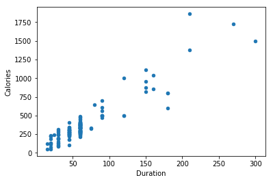

```python
import pandas as pd
import matplotlib.pyplot as plt

df = pd.read_csv('datapandas.csv')

df.plot(kind = 'scatter', x = 'Duration', y = 'Calories')

plt.show()
```

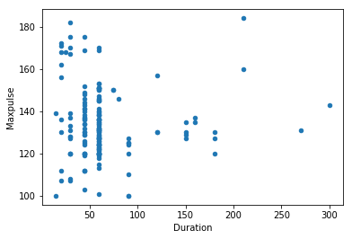

```python
import pandas as pd
import matplotlib.pyplot as plt

df = pd.read_csv('datapandas.csv')

df.plot(kind = 'scatter', x = 'Duration', y = 'Maxpulse')

plt.show()
```

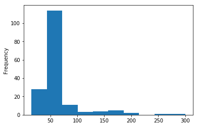

```python
df["Duration"].plot(kind = 'hist')
```

# Numpy

```python
import numpy as np

arr = np.array([1, 2, 3, 4, 5])

print(arr)

print(type(arr))
```

```
[1 2 3 4 5]
<class 'numpy.ndarray'>
```

```python
import numpy as np

print(np.__version__)
```

```
1.14.3
```

```python
# Use a tuple to create a NumPy array:

import numpy as np

arr = np.array((1, 2, 3, 4, 5))

print(arr)
```

```
[1 2 3 4 5]
```

```python
import numpy as np

arr = np.array([1, 2, 3, 4])

print(arr[0])
print(arr[1])
```

```
1
2
```

```python
import numpy as np

arr = np.array([1, 2, 3, 4])

print(arr[2] + arr[3])
```

```
7
```

```python
import numpy as np

arr = np.array([[1,2,3,4,5], [6,7,8,9,10]])

print('2nd element on 1st row: ', arr[0, 1])
```

```
2nd element on 1st row:  2
```

```python
import numpy as np

arr = np.array([[1,2,3,4,5], [6,7,8,9,10]])

print('5th element on 2nd row: ', arr[1, 4])
```

```
5th element on 2nd row:  10
```

```python
import numpy as np

arr = np.array([[[1, 2, 3], [4, 5, 6]], [[7, 8, 9], [10, 11, 12]]])

print(arr[0, 1, 2])
```

```
6
```

```python
import numpy as np

arr = np.array([[1,2,3,4,5], [6,7,8,9,10]])

print('Last element from 2nd dim: ', arr[1, -1])
```

```
Last element from 2nd dim:  10
```

```python
import numpy as np

arr = np.array([1, 2, 3, 4, 5, 6, 7])

print(arr[1:5])
```

```
[2 3 4 5]
```

```python
import numpy as np

arr = np.array([1, 2, 3, 4, 5, 6, 7])

print(arr[4:])
```

```
[5 6 7]
```

```python
import numpy as np

arr = np.array([1, 2, 3, 4, 5, 6, 7])

print(arr[:4])
```

```
[1 2 3 4]
```

```python
import numpy as np

arr = np.array([1, 2, 3, 4, 5, 6, 7])

print(arr[-3:-1])
```

```
[5 6]
```

```python
# step
import numpy as np

arr = np.array([1, 2, 3, 4, 5, 6, 7])

print(arr[1:5:2])
```

```
[2 4]
```

```python
# Return every other element from the entire array:
import numpy as np

arr = np.array([1, 2, 3, 4, 5, 6, 7])

print(arr[::2])
```

```
[1 3 5 7]
```

```python
#From the second element, slice elements from index 1 to index 4 (not included):

import numpy as np

arr = np.array([[1, 2, 3, 4, 5], [6, 7, 8, 9, 10]])

print(arr[1, 1:4])
```

```
[7 8 9]
```

```python
# From both elements, return index 2:

import numpy as np

arr = np.array([[1, 2, 3, 4, 5], [6, 7, 8, 9, 10]])

print(arr[0:2, 2])
```

```
[3 8]
```

```python
# From both elements, slice index 1 to index 4 (not included), this will return a 2-D array:

import numpy as np

arr = np.array([[1, 2, 3, 4, 5], [6, 7, 8, 9, 10]])

print(arr[0:2, 1:4])
```

```
[[2 3 4]
 [7 8 9]]
```

By default Python have these data types:

-strings - used to represent text data, the text is given under quote marks. e.g. "ABCD"

-integer - used to represent integer numbers. e.g. -1, -2, -3

-float - used to represent real numbers. e.g. 1.2, 42.42

-boolean - used to represent True or False.

-complex - used to represent complex numbers. e.g. 1.0 + 2.0j, 1.5 + 2.5j

```python
import numpy as np

arr = np.array([1, 2, 3, 4])

print(arr.dtype)
```

```
int32
```

```python
import numpy as np

arr = np.array(['apple', 'banana', 'cherry'])

print(arr.dtype)
```

```
<U6
```

```python
import numpy as np

arr = np.array([1, 2, 3, 4, 5])
x = arr.copy()
arr[0] = 42

print(arr)
print(x)
```

```
[42  2  3  4  5]
[1 2 3 4 5]
```

```python
import numpy as np

arr = np.array([1, 2, 3, 4, 5])
x = arr.view()
arr[0] = 42

print(arr)
print(x)
```

```
[42  2  3  4  5]
[42  2  3  4  5]
```

```python
import numpy as np

arr = np.array([1, 2, 3, 4, 5])
x = arr.view()
x[0] = 31

print(arr)
print(x)
```

```
[31  2  3  4  5]
[31  2  3  4  5]
```

```python
import numpy as np

arr = np.array([[1, 2, 3, 4], [5, 6, 7, 8]])

print(arr.shape)
```

```
(2, 4)
```

```python
import numpy as np

arr = np.array([1, 2, 3, 4], ndmin=5)

print(arr)
print('shape of array :', arr.shape)
```

```
[[[[[1 2 3 4]]]]]
shape of array : (1, 1, 1, 1, 4)
```

```python
# reshape

import numpy as np

arr = np.array([1, 2, 3, 4, 5, 6, 7, 8, 9, 10, 11, 12])

newarr = arr.reshape(4, 3)

print(newarr)
```

```
[[ 1  2  3]
 [ 4  5  6]
 [ 7  8  9]
 [10 11 12]]
```

```python
#Reshape From 1-D to 3-D

import numpy as np

arr = np.array([1, 2, 3, 4, 5, 6, 7, 8, 9, 10, 11, 12])

newarr = arr.reshape(2, 3, 2)

print(newarr)
```

```
[[[ 1  2]
  [ 3  4]
  [ 5  6]]

 [[ 7  8]
  [ 9 10]
  [11 12]]]
```

```python
import numpy as np

arr1 = np.array([1, 2, 3])

arr2 = np.array([4, 5, 6])

arr = np.concatenate((arr1, arr2))

print(arr)
```

```
[1 2 3 4 5 6]
```

```python
import numpy as np

arr1 = np.array([[1, 2], [3, 4]])

arr2 = np.array([[5, 6], [7, 8]])

arr = np.concatenate((arr1, arr2), axis=1)
print(arr)

arr = np.concatenate((arr1, arr2), axis=0)
print(arr)
```

```
[[1 2 5 6]
 [3 4 7 8]]
[[1 2]
 [3 4]
 [5 6]
 [7 8]]
```

```python
import numpy as np

arr1 = np.array([1, 2, 3])

arr2 = np.array([4, 5, 6])

arr = np.stack((arr1, arr2), axis=1)

print(arr)
```

```
[[1 4]
 [2 5]
 [3 6]]
```

```python
import numpy as np

arr1 = np.array([1, 2, 3])

arr2 = np.array([4, 5, 6])

arr = np.hstack((arr1, arr2))

print(arr)
```

```
[1 2 3 4 5 6]
```

```python
import numpy as np

arr1 = np.array([1, 2, 3])

arr2 = np.array([4, 5, 6])

arr = np.vstack((arr1, arr2))

print(arr)
```

```
[[1 2 3]
 [4 5 6]]
```

```python
import numpy as np

arr1 = np.array([1, 2, 3])

arr2 = np.array([4, 5, 6])

arr = np.dstack((arr1, arr2))

print(arr)
```

```
[[[1 4]
  [2 5]
  [3 6]]]
```

```python
import numpy as np

arr = np.array([1, 2, 3, 4, 5, 6])

newarr = np.array_split(arr, 3)

print(newarr)
```

```
[array([1, 2]), array([3, 4]), array([5, 6])]
```

```python
import numpy as np

arr = np.array([1, 2, 3, 4, 5, 6])

newarr = np.array_split(arr, 4)

print(newarr[1])
```

```
[3 4]
```

```python
#Find the indexes where the value is 4:

import numpy as np

arr = np.array([1, 2, 3, 4, 5, 4, 4])

x = np.where(arr == 4)

print(x)
```

```
(array([3, 5, 6], dtype=int64),)
```

```python
#Find the indexes where the values are even:

import numpy as np

arr = np.array([1, 2, 3, 4, 5, 6, 7, 8])

x = np.where(arr%2 == 0)

print(x)
```

```
(array([1, 3, 5, 7], dtype=int64),)
```

```python
#Find the indexes where the values are odd:

import numpy as np

arr = np.array([1, 2, 3, 4, 5, 6, 7, 8])

x = np.where(arr%2 == 1)

print(x)
```

```
(array([0, 2, 4, 6], dtype=int64),)
```

```python
import numpy as np

arr = np.array([3, 2, 0, 1])

print(np.sort(arr))
```

```
[0 1 2 3]
```

```python
import numpy as np

arr = np.array([True, False, True])

print(np.sort(arr))
```

```
[False  True  True]
```

```python
import numpy as np

arr = np.array([[3, 2, 4], [5, 0, 1]])

print(np.sort(arr))
```

```
[[2 3 4]
 [0 1 5]]
```

```python
import numpy as np

arr = np.array([41, 42, 43, 44])

x = [True, False, True, False]

newarr = arr[x]

print(newarr)
```

```
[41 43]
```

```python
#Create a filter array that will return only values higher than 42:

import numpy as np

arr = np.array([41, 42, 43, 44])

# Create an empty list
filter_arr = []

# go through each element in arr
for element in arr:
  # if the element is higher than 42, set the value to True, otherwise False:
  if element > 42:
    filter_arr.append(True)
  else:
    filter_arr.append(False)

newarr = arr[filter_arr]

print(filter_arr)
print(newarr)
```

```
[False, False, True, True]
[43 44]
```

```python
# Create a filter array that will return only even elements from the original array:

import numpy as np

arr = np.array([1, 2, 3, 4, 5, 6, 7])

# Create an empty list
filter_arr = []

# go through each element in arr
for element in arr:
  # if the element is completely divisble by 2, set the value to True, otherwise False
  if element % 2 == 0:
    filter_arr.append(True)
  else:
    filter_arr.append(False)

newarr = arr[filter_arr]

print(filter_arr)
print(newarr)
```

```
[False, True, False, True, False, True, False]
[2 4 6]
```

```python
# Create a filter array that will return only values higher than 42:

import numpy as np

arr = np.array([41, 42, 43, 44])

filter_arr = arr > 42

newarr = arr[filter_arr]

print(filter_arr)
print(newarr)
```

```
[False False  True  True]
[43 44]
```

```python
# Create a filter array that will return only even elements from the original array:

import numpy as np

arr = np.array([1, 2, 3, 4, 5, 6, 7])

filter_arr = arr % 2 == 0

newarr = arr[filter_arr]

print(filter_arr)
print(newarr)
```

```
[False  True False  True False  True False]
[2 4 6]
```